# BIOL606_hw_Lec17_Hastings

2025-04-16

# Homework Lecture 18

*Visualize the data distribution for each compound. Should you log transform the data?*

Transformed data via transform_if_needed function.

```r
# Function to apply transformation based on skewness.
transform_if_needed <- function(x) {
  sk <- skewness(x, na.rm = TRUE)

  # If right-skewed and all values > 0, use log.
  if (sk > 1 && all(x > 0, na.rm = TRUE)) {
    return(log(x))
  }
  # If moderately skewed and all values ≥ 0, try square root.
  else if (sk > 0.5 && all(x >= 0, na.rm = TRUE)) {
    return(sqrt(x))
  }
  # Otherwise, return original.
  return(x)
}
```

```r
trego <- read_csv('Trego2018.csv') # Read in data from local directory.
```

```r
# Convert ID variable to factor variable.
trego$ID <- factor(trego$ID)

# Convert categorical variable 'Maturity' to factor variable. Label factors for plotting purposes later.
trego$Maturity <- factor(
  trego$Maturity,
  levels = c('I', 'M'),
  labels = c('immature', 'mature')
)

# Check the structure of the data.
glimpse(trego)
```

```
## Rows: 14
## Columns: 35
## $ ID                           <fct> BXD0003, BXD0036, CXG0035, CYM0100, EPM02…
## $ Maturity                     <fct> mature, mature, immature, immature, immat…
## $ B.CDE                        <dbl> 0.004140827, 0.000000000, 0.000000000, 0.…
## $ Brominated.anisole           <dbl> 0.006780591, 0.015453889, 0.004219515, 0.…
## $ Brominated.indole            <dbl> 0.007589854, 0.000000000, 0.015621590, 0.…
## $ Chlordane.related            <dbl> 4.6609932, 0.6750341, 1.6178049, 1.719964…
## $ Chlorinated.benzene          <dbl> 0.9332563, 0.9282561, 1.2235712, 0.812214…
## $ Chlorinated.styrene          <dbl> 0.009085100, 0.000000000, 0.000000000, 0.…
## $ Chlorobenzaldehyde           <dbl> 0.0000000, 0.1490176, 0.0000000, 0.000000…
## $ DDT.related                  <dbl> 9.803949, 6.484796, 4.342030, 4.541701, 4…
## $ Dichlorobenzophenone         <dbl> 0.0000000, 0.0000000, 0.0000000, 0.000000…
## $ DMBP                         <dbl> 3.500432, 3.799111, 3.300395, 4.334300, 2…
## $ HCH.related                  <dbl> 0.7481924, 1.2092543, 1.0466753, 1.191826…
```

[output cut: 22 more lines]

```r
# Check basic properties.
summary(trego)
```

```
##        ID        Maturity     B.CDE          Brominated.anisole
##  BXD0003:1   immature:6   Min.   :0.000000   Min.   :0.000000
##  BXD0036:1   mature  :8   1st Qu.:0.000000   1st Qu.:0.003286
##  CXG0035:1                Median :0.000000   Median :0.006531
##  CYM0100:1                Mean   :0.001587   Mean   :0.014104
##  EPM0299:1                3rd Qu.:0.003200   3rd Qu.:0.014278
##  JEA0085:1                Max.   :0.008514   Max.   :0.102735
##  (Other):8
##  Brominated.indole  Chlordane.related Chlorinated.benzene Chlorinated.styrene
##  Min.   :0.000000   Min.   :0.675     Min.   :0.6044      Min.   :0.000000
##  1st Qu.:0.000000   1st Qu.:1.616     1st Qu.:0.8256      1st Qu.:0.000000
##  Median :0.005362   Median :1.795     Median :0.9308      Median :0.002999
##  Mean   :0.011466   Mean   :2.530     Mean   :1.1227      Mean   :0.006753
##  3rd Qu.:0.009202   3rd Qu.:3.932     3rd Qu.:1.1829      3rd Qu.:0.008896
##  Max.   :0.084578   Max.   :4.949     Max.   :2.8044      Max.   :0.044190
##
##  Chlorobenzaldehyde  DDT.related    Dichlorobenzophenone      DMBP
##  Min.   :0.0000     Min.   :4.342   Min.   :0.0000       Min.   :2.011
##  1st Qu.:0.0000     1st Qu.:5.139   1st Qu.:0.0000       1st Qu.:2.808
##  Median :0.0000     Median :6.569   Median :0.0000       Median :3.232
##  Mean   :0.0124     Mean   :6.870   Mean   :0.1403       Mean   :3.181
##  3rd Qu.:0.0000     3rd Qu.:8.417   3rd Qu.:0.0000       3rd Qu.:3.536
##  Max.   :0.1490     Max.   :9.923   Max.   :1.1561       Max.   :4.334
##
##   HCH.related     Heptachlor.related      MBP           MeO.B.CDE
##  Min.   :0.6679   Min.   :0.0000     Min.   :0.0719   Min.   :0.000000
##  1st Qu.:1.0574   1st Qu.:0.1042     1st Qu.:0.2805   1st Qu.:0.005595
##  Median :1.1656   Median :0.1350     Median :0.4509   Median :0.007117
##  Mean   :1.2095   Mean   :0.1350     Mean   :0.4580   Mean   :0.007929
##  3rd Qu.:1.2568   3rd Qu.:0.1634     3rd Qu.:0.6853   3rd Qu.:0.009356
##  Max.   :2.1788   Max.   :0.3149     Max.   :0.8716   Max.   :0.019291
##
##     MeO.BDE           MeO.PBB         Methylenebistrichloroanisole
##  Min.   :0.06179   Min.   :0.008473   Min.   :0.0000
##  1st Qu.:0.10620   1st Qu.:0.030056   1st Qu.:0.0333
##  Median :0.11881   Median :0.039210   Median :0.1274
##  Mean   :0.12220   Mean   :0.044439   Mean   :0.1694
##  3rd Qu.:0.12946   3rd Qu.:0.064068   3rd Qu.:0.2130
##  Max.   :0.25590   Max.   :0.082146   Max.   :0.7069
##
```

[output cut: 25 more lines]

```
##  Min.   :0.00000   Min.   :0.00000   Min.   :0.000000   Min.   :0.000000
##  1st Qu.:0.00000   1st Qu.:0.00000   1st Qu.:0.000000   1st Qu.:0.000000
##  Median :0.01931   Median :0.01003   Median :0.000000   Median :0.000000
##  Mean   :0.03299   Mean   :0.01808   Mean   :0.001995   Mean   :0.005302
##  3rd Qu.:0.06561   3rd Qu.:0.02716   3rd Qu.:0.002312   3rd Qu.:0.005077
##  Max.   :0.10057   Max.   :0.08916   Max.   :0.017452   Max.   :0.032386
##
##    Unknown.8
##  Min.   :0.00000
##  1st Qu.:0.02418
##  Median :0.07327
##  Mean   :0.18063
##  3rd Qu.:0.23561
##  Max.   :0.76684
##
```

```r
# View the names and types of all columns.
spec(trego)
# Peek at 5 random rows.
trego |>
  slice_sample(n = 5)
```

```
## # A tibble: 5 × 35
##   ID     Maturity   B.CDE Brominated.anisole Brominated.indole Chlordane.related
##   <fct>  <fct>      <dbl>              <dbl>             <dbl>             <dbl>
## 1 KSS00… mature   0                  0.00387           0                    2.54
## 2 TCL00… mature   0                  0.0135            0.00367              4.45
## 3 SMH00… mature   0                  0.00238           0.00676              4.29
## 4 PBW00… mature   0.00365            0                 0.00883              2.86
## 5 KAS01… immature 0                  0.103             0                    1.87
## # ℹ 29 more variables: Chlorinated.benzene <dbl>, Chlorinated.styrene <dbl>,
## #   Chlorobenzaldehyde <dbl>, DDT.related <dbl>, Dichlorobenzophenone <dbl>,
## #   DMBP <dbl>, HCH.related <dbl>, Heptachlor.related <dbl>, MBP <dbl>,
## #   MeO.B.CDE <dbl>, MeO.BDE <dbl>, MeO.PBB <dbl>,
## #   Methylenebistrichloroanisole <dbl>, Methylsulfonyl.PCB <dbl>,
## #   Mirex.related <dbl>, PBB <dbl>, PBDE <dbl>, PBHD <dbl>,
## #   Pyrrolidinecarbonyl.chloride <dbl>, TCPM <dbl>, TCPMOH <dbl>, …
```

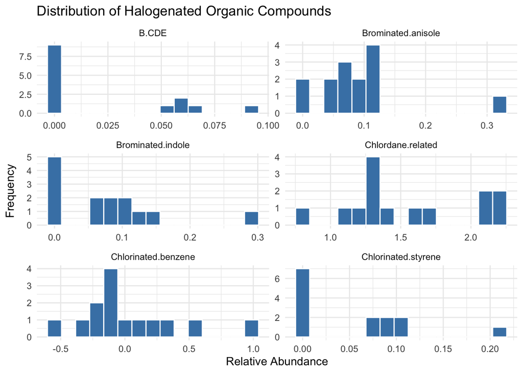

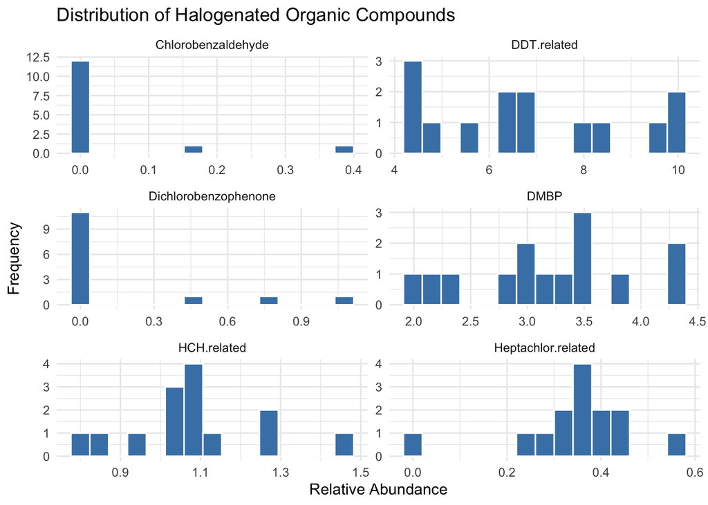

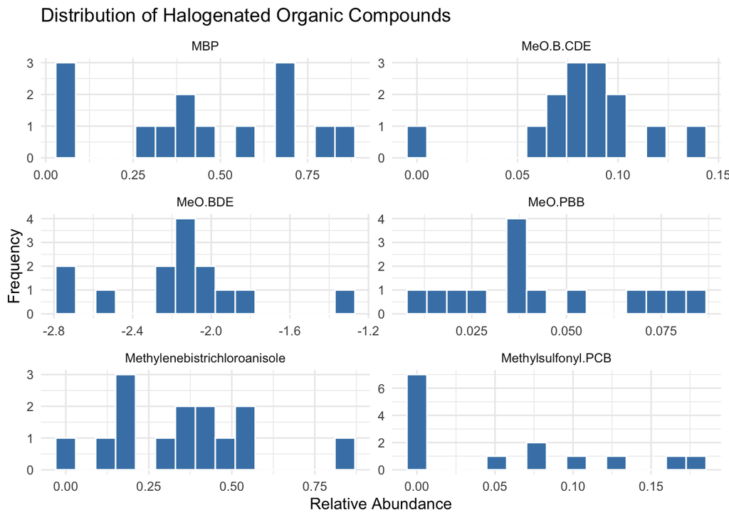

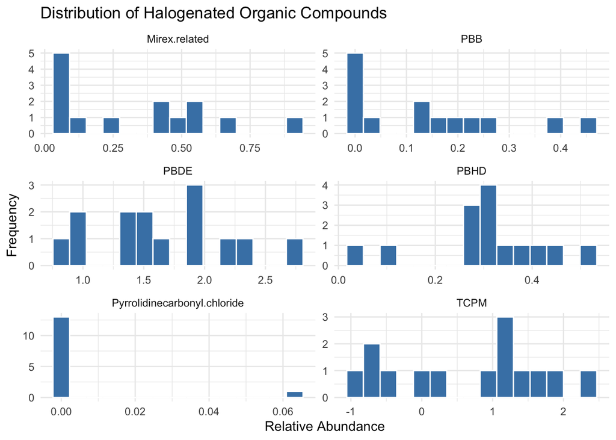

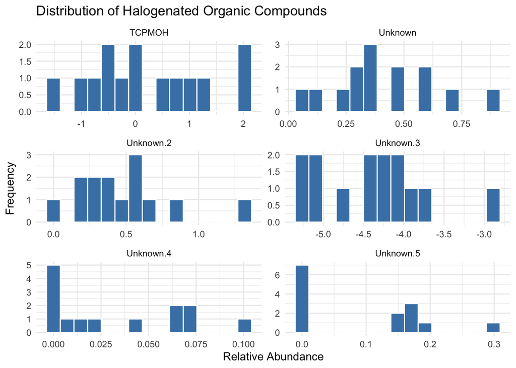

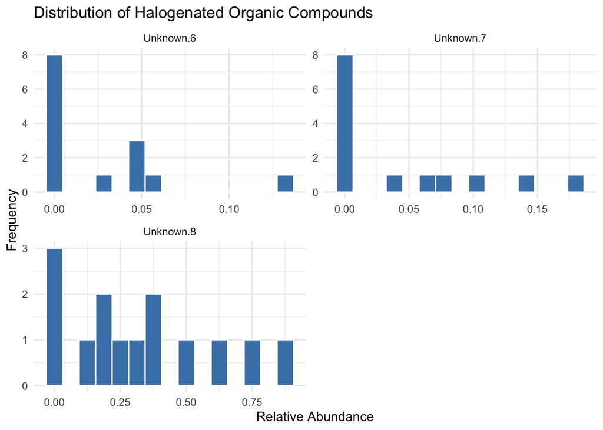

```r
# Transform compound columns (3:35) if needed.
trego_transformed <- trego
trego_transformed[ , 3:35] <- lapply(trego[ , 3:35], transform_if_needed)

# Convert the data to long format (maturity is column 2, compounds are columns 3:35) for plotting purposes.
trego_long <- trego_transformed |>
  pivot_longer(cols = 3:35, names_to = 'compound', values_to = 'abundance')

# Split the list of unique compound names into chunks of 6 compounds each.
compound_chunks <- split(
  unique(trego_long$compound),
  ceiling(seq_along(unique(trego_long$compound)) / 6)
)

# Loop through each chunk and generate a separate plot.
for (chunk in compound_chunks) {
  # Subset the data to only include the current chunk of compounds.
  plt <- ggplot(trego_long[trego_long$compound %in% chunk, ], aes(x = abundance)) +
    # Create histogram for the abundance of each compound.
    geom_histogram(bins = 15, fill = 'steelblue', color = 'white') +
    # Use facet_wrap to create a subplot for each compound in the chunk.
    facet_wrap(~ compound, scales = 'free', ncol = 2) +
    theme_minimal() +
    # Add plot labels.
    labs(
      title = 'Distribution of Halogenated Organic Compounds',
      x = 'Relative Abundance',
      y = 'Frequency'
    )

  # Print the plot for the current chunk.
  print(plt)
}
```

*Perform a PCA (i.e. PCoA using Euclidean distance).*

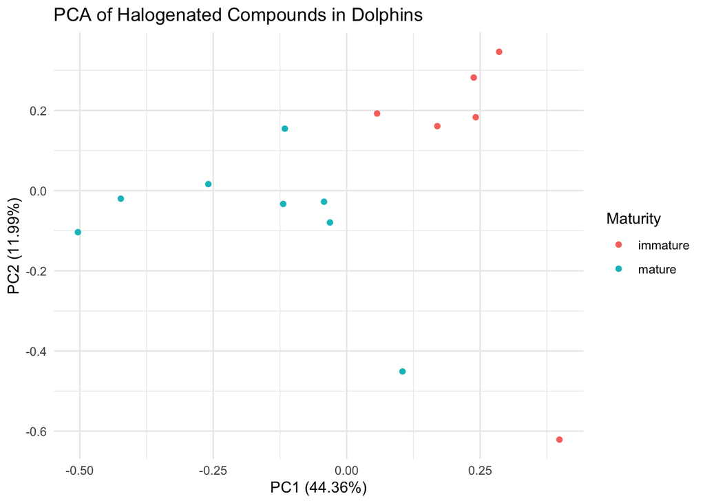

```r
# Select compound data only for PCA (columns 3 to 35).
compound_data <- trego_transformed[, 3:ncol(trego_transformed)]

# Perform PCA - center and scale the variables.
compound_pca <- prcomp(compound_data, center = TRUE, scale. = TRUE)

# Attach Maturity info for plotting.
autoplot(compound_pca, data = trego_transformed, colour = 'Maturity') +
  theme_minimal() +
  labs(title = 'PCA of Halogenated Compounds in Dolphins')
```

*Show the relationship between the dolphins and the compounds using a biplot.*

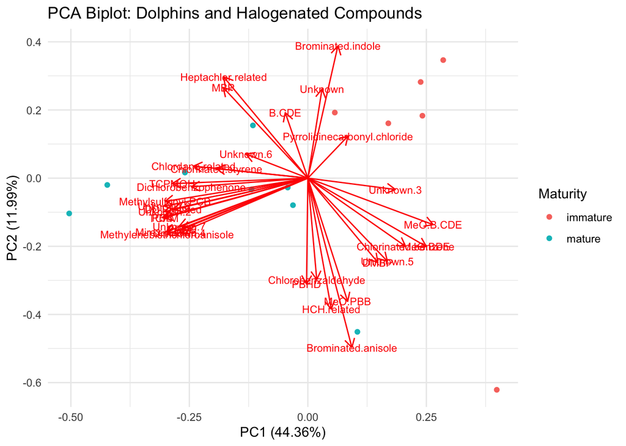

```r
autoplot(
  compound_pca,
  data = trego_transformed,
  colour = 'Maturity',
  loadings = TRUE,
  loadings.label = TRUE,
  loadings.label.size = 3
) +
  labs(title = 'PCA Biplot: Dolphins and Halogenated Compounds',
       colour = 'Maturity') +
  theme_minimal()
```

*Find the most important compounds with the help of a contribution plot (fviz_contrib), subset the data and re-run PCA with only those compounds that fall above the red line on the contribution plot.*

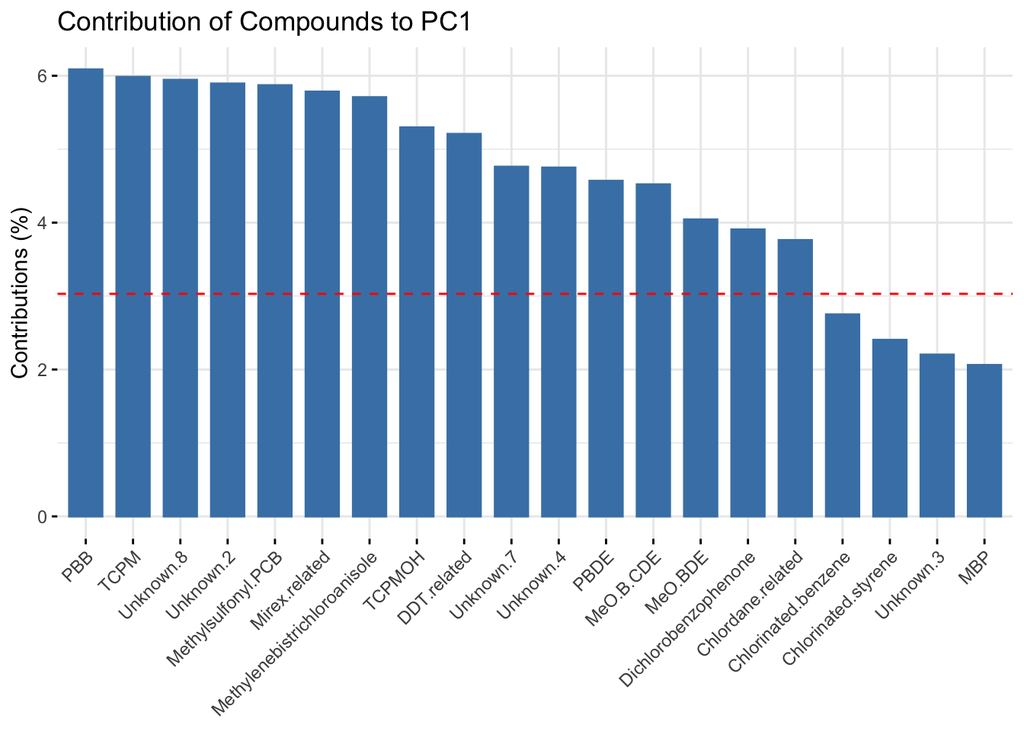

```r
# Plot shows how much each compound contributes to variation in PC1.- Red line marks the average expected contribution — compounds above it contribute more than average.
fviz_contrib(compound_pca, choice = 'var', axes = 1, top = 20) +
  labs(title = 'Contribution of Compounds to PC1')
```

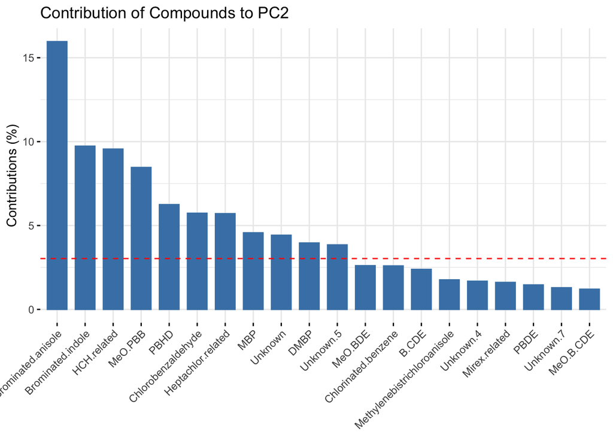

```r
fviz_contrib(compound_pca, choice = 'var', axes = 2, top = 20) +
  labs(title = 'Contribution of Compounds to PC2')
```

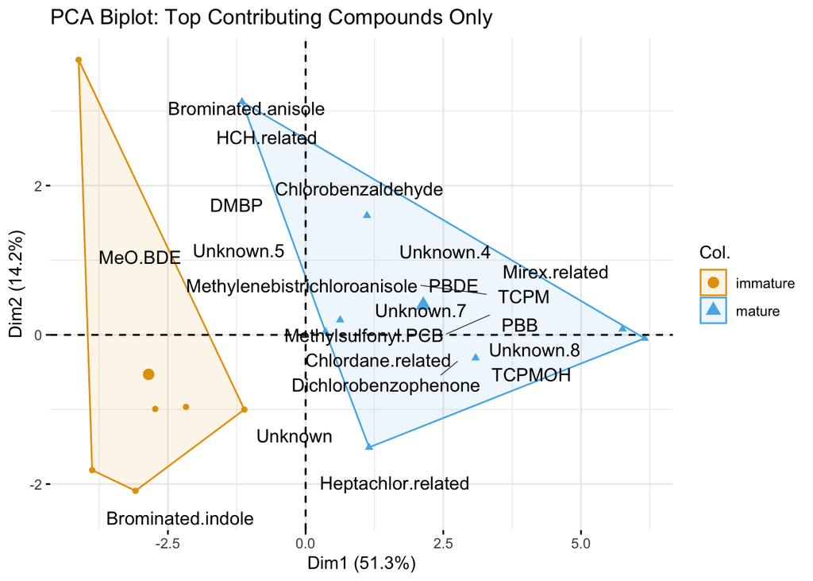

```r
# Manually identify important compounds in the plots.
important_vars <- c('PBB', 'TCPM', 'Unknown.8', 'Methylsulfonyl.PCB', 'Mirex.related', 'Methylenebistrichloroanisole', 'TCPMOH', 'Unknown.7', 'Unknown.4', 'PBDE', 'MeO.BDE', 'Dichlorobenzophenone', 'Chlordane.related', 'Brominated.anisole', 'Brominated.indole', 'HCH.related', 'Chlorobenzaldehyde', 'Heptachlor.related', 'Unknown', 'DMBP', 'Unknown.5')

# Subset data to only include compounds important to PC1 or PC2.
compound_data_top <- trego_transformed[, important_vars]

# Re-run PCA.
compound_pca_top <- prcomp(compound_data_top, center = TRUE, scale. = TRUE)

# Re-create a PCA biplot using only the top contributing compounds.
fviz_pca_biplot(
  compound_pca_top,
  geom.ind = 'point',
  col.ind = trego_transformed$Maturity,  # Color points by dolphin maturity class (immature vs mature).
  palette = c('#E69F00', '#56B4E9'),
  addEllipses = TRUE, # Add ellipses to group by maturity.
  ellipse.type = 'convex',
  label = 'var',
  col.var = 'black',
  arrowsize = 0, # Hide arrows.
  repel = TRUE # Use repelling to prevent overlapping text labels.
) +
  labs(title = 'PCA Biplot: Top Contributing Compounds Only')
```

*Based on the final biplot, are different compounds associated more with immature than mature dolphins? Write your answer in the R code as a comment or in text outside the R code chunk.*

This clear separation suggests that the chemical profiles of immature and mature dolphins differ.